# We R Champions

Syllabus for the *We R Champions* masterclass series

Alexander Savi, Amsterdam Center for Learning Analytics

Simone Plak, Amsterdam Center for Learning Analytics

September 16, 2020

# R?

Yes, because A to Q are silly, we skip right over to R. R is a free and open-source programming language for statistical analyses.

Sounds boring? It can do visualizations too! And interactive visualizations, even animations, if you fancy. It can do documents with integrated code and output (this syllabus was written in R). And it can even do presentations, journal articles, books, websites, what not!

Well, there’s a lot it cannot do. For one, it won’t do your dishes. And you’ll have to learn to program. That’s doing your analyses without a mouse; just you and the keyboard.

In return, you’ll be able to use the [most popular](https://r4stats.com/articles/popularity/) and most powerful statistical software presently available. Its community built [over 15000 extensions](https://gist.github.com/daroczig/3cf06d6db4be2bbe3368) that are free for you to use. Ever wanted to perform a Bayesian binomial SEM ninja analysis with adaptive non-parametric splines? R can do, probably. As well as an ANOVA.

As well as ASCII art (code is shown with output directly below it):

```r
cowsay::say("We R Champions")
```

```
 --------------
We R Champions
 --------------
    \
      \
        \
            |\___/|
          ==) ^Y^ (==
            \  ^  /
             )=*=(
            /     \
            |     |
           /| | | |\
           \| | |_|/\
      jgs  //_// ___/
               \_)
```

Want to use R? It’s simple. Sign up for our R Masterclass Series and start learning.

# Takeaway

The series includes several modular masterclasses, on data analysis, data transformation, data visualization, data communication, and reproducibility.

- Instructors: [Alexander Savi](https://www.alexandersavi.nl/) and [Simone Plak](https://www.researchgate.net/profile/Simone_Plak).
- Lingua franca: Dutch or Dunglish, depending on the participants.
- Sign up: you’ll receive a sign-up link in your mail. Drop us a line if you want to be sure to get it.

# Content

*Note that the recommended and nerd masterclasses are conditional on sufficient interest and available time.*

## We R Novices

In *We R Novices* you’ll learn..

- how to set up R
- what R can be used for
- how to use RStudio Desktop
- how to use good programming habits (projects, scripts, comments)
- how to navigate through R space (packages, vignettes, cheat sheets, Q&A)
- how to continue to learn and use R on your own
- how to use R without having to program

In *We R Novices* you’ll NOT learn..

- base R. Or at least not all of it. Because even though it’s the basis, it’s advanced. You’ll be able to learn it in the *We R Programmers* masterclass.
- how to do data analysis. You’ll learn it in the follow-up *We R Analysts* masterclass.
- how to get your data transformed and tidied. Instead, use your favorite data editor or learn how to do it in R in the *We R Transformers* masterclass.
- how to create figures. Becoming an artist takes more than an hour, but you’ll be able to learn it in the *We R Visualizers* masterclass.
- how to become an R ninja. Take the *We R Reproducible*, *We R Publishers*, and *We R Programmers* masterclasses to become a Master of Rts.

## We R Analysts

In *We R Analysts* you’ll learn..

- how to import data from Excel, SPSS, SAS, Stata, and R, using the *[readr](https://readr.tidyverse.org/)*, *[haven](https://haven.tidyverse.org/)*, and *[readxl](https://readxl.tidyverse.org/)* packages
- how to compute descriptive statistics
- how to perform basic statistical analyses
- how to check common assumptions

## We R Transformers

In *We R Transformers* you’ll learn..

- how to transform and tidy your data for your specific needs, using the *[tidyr](https://tidyr.tidyverse.org/)* and *[dplyr](https://dplyr.tidyverse.org/)* packages
- how to transform date variables, time variables, text variables, and factor variables, using the *[lubridate](https://lubridate.tidyverse.org/)*, *[hms](https://hms.tidyverse.org/)*, *[stringr](https://stringr.tidyverse.org/)*, and *[forcats](https://forcats.tidyverse.org/)* packages

## We R Visualizers

In *We R Visualizers* you’ll learn..

- how to create jaw-dropping figures, using the *[ggplot2](https://ggplot2.tidyverse.org/)* package
- how to extend *ggplot2* with [over 60 visualization techniques](https://www.ggplot2-exts.org/gallery/), including networks, animations, and tv themes
- how to export tables to Word, using the *[flextable](https://davidgohel.github.io/flextable/index.html)* package

## We R Reproducible

In *We R Reproducible* you’ll learn..

- how to get from raw data to your final maniscript, and be reproducible
- how to use version control with *[Git](https://git-scm.com/)* and *[GitHub](https://github.com/)*
- how to write reader-friendly R prose using [R style](https://style.tidyverse.org/)
- how to write share-friendly R code using projects, and packages like *[here](https://here.r-lib.org/)* and *[renv](https://rstudio.github.io/renv/)*

## We R Publishers

In *We R Publishers* you’ll learn..

- how to integrate code, output, and text (like in this syllabus)
- how to make presentations in R
- how to create and publish interactive applications with [R Shiny](https://shiny.rstudio.com/)
- how to write and publish journal articles and books with R
- how to build websites with R
- how to check your manuscripts, using the *[statcheck](https://mbnuijten.com/statcheck/)* and *retractcheck* packages

## We R Programmers

In *We R Programmers* you’ll learn..

- base R
- how to write explicit and implicit loops
- how to write your own R functions
- how to build your own R packages
- how to run simulations

# Organization

## Instructors

You get two for the price of one.

- Alexander Savi (contact) taught Basic Skills in Statistics (in R) and Programming The Next Step. He has over ten years of R experience.
- Simone Plak (contact) taught Programming in Psychological Science (in R). She has over six years of R experience.

Both of us have lots of R experience and don’t get angry easily, so you’ll be in good hands.

## Order

The masterclasses are modular. Don’t know where to start? The graph below shows the recommended order to take the masterclasses.

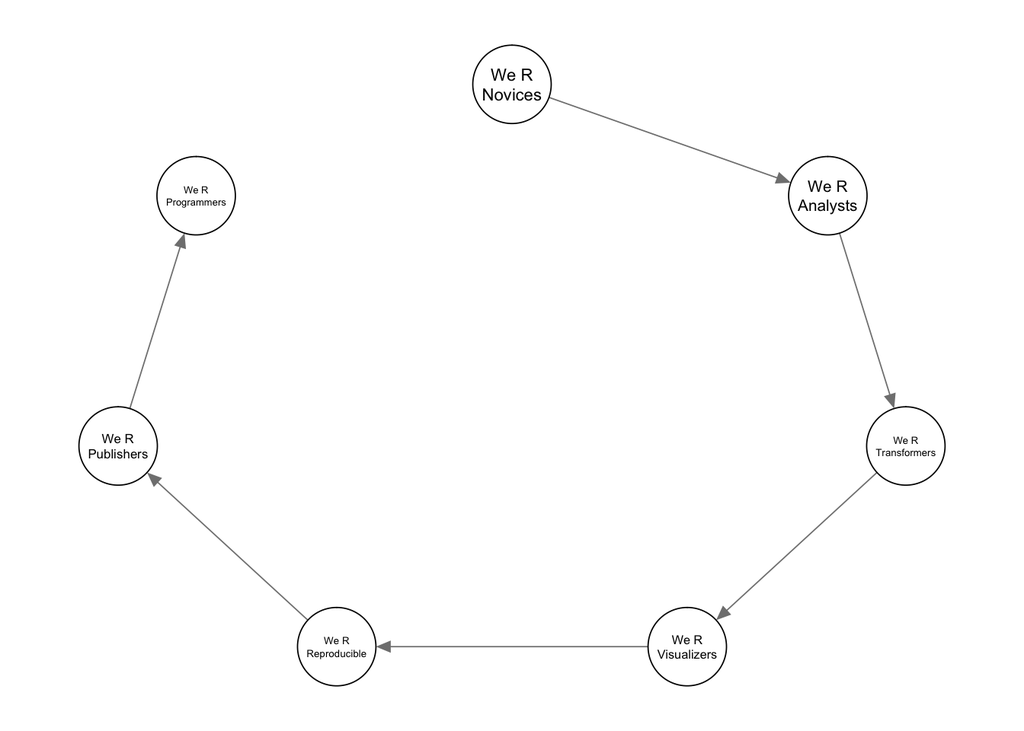

```r
masterclass_recommendation <- data.frame(
  from = c("We R\nNovices",
           "We R\nAnalysts",
           "We R\nTransformers",
           "We R\nVisualizers",
           "We R\nReproducible",
           "We R\nPublishers"),
  to = c("We R\nAnalysts",
         "We R\nTransformers",
         "We R\nVisualizers",
         "We R\nReproducible",
         "We R\nPublishers",
         "We R\nProgrammers"))

qgraph::qgraph(masterclass_recommendation, layout = "circular")
```

## Schedule

There is no fixed schedule. Get in touch to hear when the next masterclass is planned.

## Materials

For each masterclass, you’ll receive a document with its complete outline. It includes resources and exercises that you can use both during and after the masterclass. Besides the document, we’ll use three pieces of software.

- [R](https://www.r-project.org/). It’s the core software.
- [RStudio](https://rstudio.com/products/rstudio/). A terrific user interface for R.
- [Piazza](https://piazza.com/?). You’ll use it for questions and answers. Anytime during or after the masterclass, you can use it to post your R questions. Piazza helps us to *collaboratively* answer them. Yes, that’s right, you can help your fellow students. Because the questions and answers are available to all of us, we can all learn from them, or help answer them. And guess what, answering questions helps you to develop mastery yourself.

## Activities

In the documents that outline the masterclasses, different sections are color-coded. Those colors help you recognize different activities.

- Plenary activity. *Cam on / mic on.* We’re a class, so let’s make it feel like one. These are the moments we can look each other in the eyes and share the pain that optimists call learning.
- Demonstration. *Cam off / mic off.* Demonstrations guide you in your R adventures, separating main issues from side issues, keeping you on the right track. Importantly, demonstrations give you the opportunity to see everything you’ll learn in harmony, before we break it apart into all the various building blocks that you can explore on your own. As you’ll learn the most from doing it yourself, we’ll stick to the main themes and keep it short.
- Self-guided activity. *Cam off / mic off.* This is what it’s all about. You and R alone, and a little help from your fellow students and us. To begin with, we’ve added lots of resources in the documents. You’re invited to consult these resources whenever you feel like it. You may benefit from them during the exercises, or when you start exploring R on your own. Then, during the programming activities, break out rooms help you discuss the exercises in small groups. Wearing your speedpants today? See if you can help out the others by answering questions on Piazza.
- Break. *Cam on / mic on.* You’ll need one once a while. Have a (virtual) break with the others, go for a stroll, feed your hamster, whatever works for you.

## Modes

### Offline

You wish. Corona age is here.

### Online

In an online masterclass you’ll need [Zoom](https://zoom.us/). You’ll use it for the live demonstrations and for working together in break out rooms. We have three suggestions that we hope make it a nice experience.

- **More screens.** Video conferencing [drains energy](https://www.bbc.com/worklife/article/20200421-why-zoom-video-chats-are-so-exhausting) for most of us, and it can’t be blamed on your fellow students. At least not all of it. We hope the different activities keep it fresh. Using a secondary screen for this masterclass and putting it off to the side can help, but we don’t all have that luxury. You may use the *camera and microphone suggestions* that are shown with the activities above.
- **More time.** You won’t be able to finish all exercise, nor digest all information, in the short time of a masterclass. Plan to work with another student on the exercises for the remainder of the day. You’ll need to dive in to digest, and working together will greatly facilitate your learning.
- **More noise.** Is the silence at home driving you nuts? Turn on the [sound of your colleagues](https://soundofcolleagues.com/#).

# Philosophy

No, we won’t throw some Kant at you. But to get the most out of this masterclass series, you need to understand our teaching philosophy and course design decisions.

## Learn actively

Our learning philosophy in three words: practice, exercise, train, play. Okay, that were four. Synonyms. But you get the idea. And although practice makes perfect, it starts with failure. Lots of it. Learn to fail, make mistakes, fool around. What happens? Why?

Now, practice does not necessarily require our presence. But practice makes perfect only if it is deliberate. Our masterclasses aim for exactly that: facilitating deliberate practice. It helps to see them as pressure cookers: they compress demonstrations, programming activities, and discussions into a limited period of time, and provide all the necessary resources. That is, they set you on the right track for you to continue to learn on your own. Importantly, on your own does not mean all alone: you’ll benefit most from learning together, either physically or using the Piazza Q&A platform.

Ultimately, these masterclasses are like daffodils gazing at a pool of deliberate practice: you’ll only learn R by diving in right away.

## Productivity first, exploration second

The R pool is wide and deep. When learning R, you’ll be easily overwhelmed. We don’t want you to; we want you to become productive, fast. That’s why we [teach the tidyverse](http://varianceexplained.org/r/teach-tidyverse/), R’s primary dialect for data science. In the following, we explain this choice.

The programming language R was originally built for statistics. When learning R, it helps to view it as an actual *language*. Now, R is an extremely versatile language. You can talk statistics, you can talk graphics, you can talk simulations; there is not a lot you cannot talk. On top of the R language, new dialects arose that make talking some subjects more efficient. One such dialect is the *tidyverse*, a dialect designed for data science.

The tidyverse is great for data wrangling, data analysis, data visualization; pretty much everything that starts with data. Importantly, it has a moderate learning curve. Base R does all that tidyverse does, and much more: you can run simulations, write loops, if statements, functions, packages. But, it has a much steeper learning curve, and most of you won’t ever get to use all of that.

We like to compare base R and tidyverse with a tompouce. Base R is the boggy basis. It allows you to do virtually anything you can imagine, in many different ways. It’s anarchistic and versatile. Tidyverse on the other hand, is the crispy sweet layer on top. It has a strong design philosophy, is easier to learn, and even looks tastier. But it pays a price, it’s much stricter and has a limited scope. It’s totalitarian and principled.

[figure not shown]

Base R and the tidyverse

We believe that the tidyverse is the shortest route to productivity. In the masterclasses, we take the tidyverse route and only take detours if we believe it significantly aids your understanding. That’s not to say we think you should only exploit R, and never explore R. However, we believe that your explorations will be more fruitful as soon as you have started to become productive.

Finally, learning the tidyverse doesn’t mean you won’t learn base R. For one, you’ll always need base R to some extend, but you’ll just need it a lot less. Moreover, you’ll encounter base R a lot when researching your programming problems online, and we want you to recognize the differences. Finally, for those who want to exploit the full potential of R, we cover base R extensively in the *We R Programmers* masterclass.

## Foundations first, surface second

When learning a new language, you don’t aim for fluency right away. That is, you won’t start engaging in philosophical discussions about your deeper emotions with a native right away. Lucky native. In other words, this masterclass series won’t teach you to become an R developer. Rather, we focus on the foundations first; the syntax, the grammar. The *We R Novices* masterclass gives you all that.

Then, the fun part is to make yourself understood in a variety of situations. Take the bus, order a beer, things like that. Thus, we focus on the surface second. The remaining masterclasses in the series will help you to become productive in a variety of situations: data analysis, visualizations, reproducibilty, and so on. And although they won’t teach you to become an expert, they’ll give you all the necessary tools to dig deeper on your own.

Having said that, some of you might be completely new to the R language, whereas others already know some of it and want to make themselves understood in a particular situation. To facilitate this, the masterclasses are designed to be modular. Think of them as your favorite water park: you may either start in the wading pool or skip right over to the high diving board. If you’re new to R, join the foundational *We R Novices* masterclass. You’ll get your feet wet, and by the end of it you will be able to tread water. That is, you’ll get a taste of R and be able to decide on using it. Or, if you’re familiar with the basics of R, but want to get a taste of various statistical analyses, join the *We R Analysts* masterclass. You love open science, but can’t reproduce your own results within a week time? Join the *We R Reproducible* masterclass. And so forth.